# Project: Investigate TMDB movie Dataset

- Introduction
- Data Wrangling
- Exploratory Data Analysis
- Conclusions
- References

## Introduction

I have decided to investigate the TMDB movie dataset(https://docs.google.com/document/d/e/2PACX-1vTlVmknRRnfy_4eTrjw5hYGaiQim5ctr9naaRd4V9du2B5bxpd8FEH3KtDgp8qVekw7Cj1GLk1IXdZi/pub?embedded=True). The questions I need to answer are:

- Which genres are more popular from year to year?
- What kinds of properties are associated with movies that have high revenues?

```python
import pandas as pd
import matplotlib.pyplot as plt
%matplotlib inline
```

## Data Wrangling

Let's analyze the data and see about the data types and missing values.

### General Properties

```python
df = pd.read_csv('tmdb-movies.csv')
df.head()
```

|  | id | imdb_id | popularity | budget | revenue | original_title | cast | homepage | director | tagline | ... | overview | runtime | genres | production_companies | release_date | vote_count | vote_average | release_year | budget_adj | revenue_adj |
| --- | --- | --- | --- | --- | --- | --- | --- | --- | --- | --- | --- | --- | --- | --- | --- | --- | --- | --- | --- | --- | --- |
| 0 | 135397 | tt0369610 | 32.985763 | 150000000 | 1513528810 | Jurassic World | Chris Pratt\|Bryce Dallas Howard\|Irrfan Khan\|Vi... | http://www.jurassicworld.com/ | Colin Trevorrow | The park is open. | ... | Twenty-two years after the events of Jurassic ... | 124 | Action\|Adventure\|Science Fiction\|Thriller | Universal Studios\|Amblin Entertainment\|Legenda... | 6/9/15 | 5562 | 6.5 | 2015 | 1.379999e+08 | 1.392446e+09 |
| 1 | 76341 | tt1392190 | 28.419936 | 150000000 | 378436354 | Mad Max: Fury Road | Tom Hardy\|Charlize Theron\|Hugh Keays-Byrne\|Nic... | http://www.madmaxmovie.com/ | George Miller | What a Lovely Day. | ... | An apocalyptic story set in the furthest reach... | 120 | Action\|Adventure\|Science Fiction\|Thriller | Village Roadshow Pictures\|Kennedy Miller Produ... | 5/13/15 | 6185 | 7.1 | 2015 | 1.379999e+08 | 3.481613e+08 |
| 2 | 262500 | tt2908446 | 13.112507 | 110000000 | 295238201 | Insurgent | Shailene Woodley\|Theo James\|Kate Winslet\|Ansel... | http://www.thedivergentseries.movie/#insurgent | Robert Schwentke | One Choice Can Destroy You | ... | Beatrice Prior must confront her inner demons ... | 119 | Adventure\|Science Fiction\|Thriller | Summit Entertainment\|Mandeville Films\|Red Wago... | 3/18/15 | 2480 | 6.3 | 2015 | 1.012000e+08 | 2.716190e+08 |
| 3 | 140607 | tt2488496 | 11.173104 | 200000000 | 2068178225 | Star Wars: The Force Awakens | Harrison Ford\|Mark Hamill\|Carrie Fisher\|Adam D... | http://www.starwars.com/films/star-wars-episod... | J.J. Abrams | Every generation has a story. | ... | Thirty years after defeating the Galactic Empi... | 136 | Action\|Adventure\|Science Fiction\|Fantasy | Lucasfilm\|Truenorth Productions\|Bad Robot | 12/15/15 | 5292 | 7.5 | 2015 | 1.839999e+08 | 1.902723e+09 |
| 4 | 168259 | tt2820852 | 9.335014 | 190000000 | 1506249360 | Furious 7 | Vin Diesel\|Paul Walker\|Jason Statham\|Michelle ... | http://www.furious7.com/ | James Wan | Vengeance Hits Home | ... | Deckard Shaw seeks revenge against Dominic Tor... | 137 | Action\|Crime\|Thriller | Universal Pictures\|Original Film\|Media Rights ... | 4/1/15 | 2947 | 7.3 | 2015 | 1.747999e+08 | 1.385749e+09 |

5 rows × 21 columns

```python
df.shape
```

```
(10866, 21)
```

The fields with string entries are marked as object

```python
df.dtypes
```

```
id                        int64
imdb_id                  object
popularity              float64
budget                    int64
revenue                   int64
original_title           object
cast                     object
homepage                 object
director                 object
tagline                  object
keywords                 object
overview                 object
runtime                   int64
genres                   object
production_companies     object
release_date             object
vote_count                int64
vote_average            float64
release_year              int64
budget_adj              float64
revenue_adj             float64
dtype: object
```

There are two columns for budget- budget and budget_adj.Same is the case for revenue. It makes more sense to check the adjusted values as these seem to be adjusted for inflation.

```python
df.info()
```

```
<class 'pandas.core.frame.DataFrame'>
RangeIndex: 10866 entries, 0 to 10865
Data columns (total 21 columns):
 #   Column                Non-Null Count  Dtype
---  ------                --------------  -----
 0   id                    10866 non-null  int64
 1   imdb_id               10856 non-null  object
 2   popularity            10866 non-null  float64
 3   budget                10866 non-null  int64
 4   revenue               10866 non-null  int64
 5   original_title        10866 non-null  object
 6   cast                  10790 non-null  object
 7   homepage              2936 non-null   object
 8   director              10822 non-null  object
 9   tagline               8042 non-null   object
 10  keywords              9373 non-null   object
 11  overview              10862 non-null  object
 12  runtime               10866 non-null  int64
 13  genres                10843 non-null  object
 14  production_companies  9836 non-null   object
 15  release_date          10866 non-null  object
 16  vote_count            10866 non-null  int64
 17  vote_average          10866 non-null  float64
 18  release_year          10866 non-null  int64
 19  budget_adj            10866 non-null  float64
 20  revenue_adj           10866 non-null  float64
dtypes: float64(4), int64(6), object(11)
memory usage: 1.7+ MB
```

```python
df.nunique()
```

```
id                      10865
imdb_id                 10855
popularity              10814
budget                    557
revenue                  4702
original_title          10571
cast                    10719
homepage                 2896
director                 5067
tagline                  7997
keywords                 8804
overview                10847
runtime                   247
genres                   2039
production_companies     7445
release_date             5909
vote_count               1289
vote_average               72
release_year               56
budget_adj               2614
revenue_adj              4840
dtype: int64
```

Let us check the director field. Along with the director,the homepage and the taglines are missing for some.

```python
df_nodir = df[df['director'].isnull()]
df_nodir.head()
```

|  | id | imdb_id | popularity | budget | revenue | original_title | cast | homepage | director | tagline | ... | overview | runtime | genres | production_companies | release_date | vote_count | vote_average | release_year | budget_adj | revenue_adj |
| --- | --- | --- | --- | --- | --- | --- | --- | --- | --- | --- | --- | --- | --- | --- | --- | --- | --- | --- | --- | --- | --- |
| 532 | 320996 | tt4073952 | 0.126594 | 0 | 0 | Iliza Shlesinger: Freezing Hot | Iliza Shlesinger | http://www.iliza.com/freezing-hot.html | NaN | NaN | ... | Smart and brazen comedian Iliza Shlesinger sha... | 71 | Comedy | New Wave Entertainment | 1/23/15 | 14 | 6.6 | 2015 | 0.0 | 0.0 |
| 548 | 355131 | NaN | 0.108072 | 0 | 0 | Sense8: Creating the World | Tuppence Middleton\|Bae Doona \|Brian J. Smith\|A... | NaN | NaN | NaN | ... | NaN | 25 | Documentary\|Science Fiction | Netflix | 8/10/15 | 12 | 7.5 | 2015 | 0.0 | 0.0 |
| 556 | 321160 | tt3908634 | 0.100910 | 0 | 0 | With This Ring | Regina Hall\|Jill Scott\|Eve\|Brooklyn Sudano\|Dei... | http://www.mylifetime.com/movies/with-this-ring | NaN | NaN | ... | After attending their friend Elise's (Sudano) ... | 105 | Comedy\|Romance | Lifetime Television\|Sony Pictures Television | 1/24/15 | 14 | 6.5 | 2015 | 0.0 | 0.0 |
| 1032 | 259910 | tt3591568 | 0.291253 | 0 | 0 | Marvel Studios: Assembling a Universe | Robert Downey Jr.\|Chris Hemsworth\|Chris Evans\|... | NaN | NaN | - | ... | A look at the story behind Marvel Studios and ... | 43 | TV Movie\|Documentary | Marvel Studios\|ABC Studios | 3/18/14 | 32 | 6.3 | 2014 | 0.0 | 0.0 |
| 1054 | 253675 | tt3711030 | 0.269468 | 0 | 0 | Unlocking Sherlock | Benedict Cumberbatch\|Martin Freeman\|Steven Mof... | NaN | NaN | NaN | ... | Explore how writers Steven Moffat and Mark Gat... | 60 | TV Movie\|Documentary | NaN | 1/19/14 | 11 | 7.2 | 2014 | 0.0 | 0.0 |

5 rows × 21 columns

Let us check the ones which have no production companies. Some of the entries for budget and revenue are zero which looks untrue.

```python
df_noproduction = df[df['production_companies'].isnull()]
df_noproduction.head(),df_noproduction.shape
```

```
(         id    imdb_id  popularity  budget  revenue  \
 228  300792  tt1618448    0.584363       0        0
 259  360603  tt5133572    0.476341       0        0
 295  363483  tt5133810    0.417191       0        0
 298  354220  tt3826866    0.370258       0        0
 328  308457  tt3090670    0.367617       0        0

                   original_title  \
 228            Racing Extinction
 259          Crown for Christmas
 295        12 Gifts of Christmas
 298  The Girl in the Photographs
 328                 Advantageous

                                                   cast  \
```

[output cut: 43 more lines]

Let us check the rows with budget and revenue equal to zero. That looks like almost half of the data. It seems we will do well to use popularity as the independent variable.

```python
df_nobudrev = df[(df.budget == 0) & (df.revenue == 0)]
df_nobudrev.head(),df_nobudrev.shape
```

```
(         id    imdb_id  popularity  budget  revenue  \
 74   347096  tt3478232    2.165433       0        0
 75   308369  tt2582496    2.141506       0        0
 92   370687  tt3608646    1.876037       0        0
 100  326359  tt4007502    1.724712       0        0
 101  254302  tt0462335    1.661789       0        0

                      original_title  \
 74           Mythica: The Darkspore
 75   Me and Earl and the Dying Girl
 92         Mythica: The Necromancer
 100                    Frozen Fever
 101                       High-Rise

                                                   cast  \
```

[output cut: 50 more lines]

Let us check the popularity column.

```python
df['popularity']
min(df['popularity']),max(df['popularity'])
```

```
(6.500000000000001e-05, 32.985763)
```

Let us see which are the unique values for genre and its count. Many movies can be grouped into different genres.

```python
df['genres'].unique()
df['genres'].nunique()
```

```
2039
```

Check and see if there are duplicates.

```python
sum(df.duplicated())
df[df.duplicated()]
df[df['id']==42194]
```

|  | id | imdb_id | popularity | budget | revenue | original_title | cast | homepage | director | tagline | ... | overview | runtime | genres | production_companies | release_date | vote_count | vote_average | release_year | budget_adj | revenue_adj |
| --- | --- | --- | --- | --- | --- | --- | --- | --- | --- | --- | --- | --- | --- | --- | --- | --- | --- | --- | --- | --- | --- |
| 2089 | 42194 | tt0411951 | 0.59643 | 30000000 | 967000 | TEKKEN | Jon Foo\|Kelly Overton\|Cary-Hiroyuki Tagawa\|Ian... | NaN | Dwight H. Little | Survival is no game | ... | In the year of 2039, after World Wars destroy ... | 92 | Crime\|Drama\|Action\|Thriller\|Science Fiction | Namco\|Light Song Films | 3/20/10 | 110 | 5.0 | 2010 | 30000000.0 | 967000.0 |
| 2090 | 42194 | tt0411951 | 0.59643 | 30000000 | 967000 | TEKKEN | Jon Foo\|Kelly Overton\|Cary-Hiroyuki Tagawa\|Ian... | NaN | Dwight H. Little | Survival is no game | ... | In the year of 2039, after World Wars destroy ... | 92 | Crime\|Drama\|Action\|Thriller\|Science Fiction | Namco\|Light Song Films | 3/20/10 | 110 | 5.0 | 2010 | 30000000.0 | 967000.0 |

2 rows × 21 columns

### Data Cleaning

I think popularity score would be a more accurate indicator of the acceptance of the movies.

- For the first question, I plan to remove all rows with null genre values to find which one is popular over the years.
- For the second question, I plan to use the same dataframe as above.

Remove duplicate rows. Just 1 row is duplicated.

```python
df.drop_duplicates(inplace=True)
df.shape
```

```
(10865, 21)
```

There seem to be multiple genres.

```python
df_genre = df[df['genres'].notnull()]
df_genre.head(),df_genre.shape
```

```
(       id    imdb_id  popularity     budget     revenue  \
 0  135397  tt0369610   32.985763  150000000  1513528810
 1   76341  tt1392190   28.419936  150000000   378436354
 2  262500  tt2908446   13.112507  110000000   295238201
 3  140607  tt2488496   11.173104  200000000  2068178225
 4  168259  tt2820852    9.335014  190000000  1506249360

                  original_title  \
 0                Jurassic World
 1            Mad Max: Fury Road
 2                     Insurgent
 3  Star Wars: The Force Awakens
 4                     Furious 7

                                                 cast  \
```

[output cut: 50 more lines]

Find all the possible genres.

```python
genres = df_genre['genres'].unique()
newgenres = [genre.split('|') for genre in genres]
newgenres = sum(newgenres,[])
newgenres = list(set(newgenres))
newgenres
```

```
['Science Fiction',
 'Drama',
 'Romance',
 'Action',
 'Comedy',
 'Music',
 'Family',
 'Animation',
 'TV Movie',
 'Foreign',
 'Fantasy',
 'War',
 'Mystery',
 'Horror',
 'Documentary',
 'Adventure',
 'History',
 'Thriller',
 'Western',
 'Crime']
```

Build columns with the genres, so that it can be appended to the original dataframe.

```python
new_cols = df_genre['genres'].apply(lambda x:pd.Series(x.split('|')).value_counts())
new_cols.fillna(0,inplace=True)
new_cols
```

|  | Adventure | Thriller | Science Fiction | Action | Fantasy | Crime | Drama | Western | Family | Animation | Comedy | Mystery | Romance | War | History | Music | Horror | Documentary | TV Movie | Foreign |
| --- | --- | --- | --- | --- | --- | --- | --- | --- | --- | --- | --- | --- | --- | --- | --- | --- | --- | --- | --- | --- |
| 0 | 1.0 | 1.0 | 1.0 | 1.0 | 0.0 | 0.0 | 0.0 | 0.0 | 0.0 | 0.0 | 0.0 | 0.0 | 0.0 | 0.0 | 0.0 | 0.0 | 0.0 | 0.0 | 0.0 | 0.0 |
| 1 | 1.0 | 1.0 | 1.0 | 1.0 | 0.0 | 0.0 | 0.0 | 0.0 | 0.0 | 0.0 | 0.0 | 0.0 | 0.0 | 0.0 | 0.0 | 0.0 | 0.0 | 0.0 | 0.0 | 0.0 |
| 2 | 1.0 | 1.0 | 1.0 | 0.0 | 0.0 | 0.0 | 0.0 | 0.0 | 0.0 | 0.0 | 0.0 | 0.0 | 0.0 | 0.0 | 0.0 | 0.0 | 0.0 | 0.0 | 0.0 | 0.0 |
| 3 | 1.0 | 0.0 | 1.0 | 1.0 | 1.0 | 0.0 | 0.0 | 0.0 | 0.0 | 0.0 | 0.0 | 0.0 | 0.0 | 0.0 | 0.0 | 0.0 | 0.0 | 0.0 | 0.0 | 0.0 |
| 4 | 0.0 | 1.0 | 0.0 | 1.0 | 0.0 | 1.0 | 0.0 | 0.0 | 0.0 | 0.0 | 0.0 | 0.0 | 0.0 | 0.0 | 0.0 | 0.0 | 0.0 | 0.0 | 0.0 | 0.0 |
| ... | ... | ... | ... | ... | ... | ... | ... | ... | ... | ... | ... | ... | ... | ... | ... | ... | ... | ... | ... | ... |
| 10861 | 0.0 | 0.0 | 0.0 | 0.0 | 0.0 | 0.0 | 0.0 | 0.0 | 0.0 | 0.0 | 0.0 | 0.0 | 0.0 | 0.0 | 0.0 | 0.0 | 0.0 | 1.0 | 0.0 | 0.0 |
| 10862 | 1.0 | 0.0 | 0.0 | 1.0 | 0.0 | 0.0 | 1.0 | 0.0 | 0.0 | 0.0 | 0.0 | 0.0 | 0.0 | 0.0 | 0.0 | 0.0 | 0.0 | 0.0 | 0.0 | 0.0 |
| 10863 | 0.0 | 0.0 | 0.0 | 0.0 | 0.0 | 0.0 | 0.0 | 0.0 | 0.0 | 0.0 | 1.0 | 1.0 | 0.0 | 0.0 | 0.0 | 0.0 | 0.0 | 0.0 | 0.0 | 0.0 |
| 10864 | 0.0 | 0.0 | 0.0 | 1.0 | 0.0 | 0.0 | 0.0 | 0.0 | 0.0 | 0.0 | 1.0 | 0.0 | 0.0 | 0.0 | 0.0 | 0.0 | 0.0 | 0.0 | 0.0 | 0.0 |
| 10865 | 0.0 | 0.0 | 0.0 | 0.0 | 0.0 | 0.0 | 0.0 | 0.0 | 0.0 | 0.0 | 0.0 | 0.0 | 0.0 | 0.0 | 0.0 | 0.0 | 1.0 | 0.0 | 0.0 | 0.0 |

10842 rows × 20 columns

```python
joined = df_genre.join(new_cols)
joined.shape
joined['genres'],joined[['Thriller','Adventure','Science Fiction','Action']]
```

```
(0        Action|Adventure|Science Fiction|Thriller
 1        Action|Adventure|Science Fiction|Thriller
 2               Adventure|Science Fiction|Thriller
 3         Action|Adventure|Science Fiction|Fantasy
 4                            Action|Crime|Thriller
                            ...
 10861                                  Documentary
 10862                       Action|Adventure|Drama
 10863                               Mystery|Comedy
 10864                                Action|Comedy
 10865                                       Horror
 Name: genres, Length: 10842, dtype: object,
        Thriller  Adventure  Science Fiction  Action
 0           1.0        1.0              1.0     1.0
 1           1.0        1.0              1.0     1.0
 2           1.0        1.0              1.0     0.0
 3           0.0        1.0              1.0     1.0
 4           1.0        0.0              0.0     1.0
 ...         ...        ...              ...     ...
 10861       0.0        0.0              0.0     0.0
 10862       0.0        1.0              0.0     1.0
 10863       0.0        0.0              0.0     0.0
 10864       0.0        0.0              0.0     1.0
 10865       0.0        0.0              0.0     0.0

 [10842 rows x 4 columns])
```

Let us group by year now and take the count of the movies.

```python
histValues = joined.groupby('release_year')[newgenres].sum()
histValues
```

| release_year | Science Fiction | Drama | Romance | Action | Comedy | Music | Family | Animation | TV Movie | Foreign | Fantasy | War | Mystery | Horror | Documentary | Adventure | History | Thriller | Western | Crime |
| --- | --- | --- | --- | --- | --- | --- | --- | --- | --- | --- | --- | --- | --- | --- | --- | --- | --- | --- | --- | --- |
| 1960 | 3.0 | 13.0 | 6.0 | 8.0 | 8.0 | 1.0 | 3.0 | 0.0 | 0.0 | 1.0 | 2.0 | 2.0 | 0.0 | 7.0 | 0.0 | 5.0 | 5.0 | 6.0 | 6.0 | 2.0 |
| 1961 | 4.0 | 16.0 | 7.0 | 7.0 | 10.0 | 2.0 | 5.0 | 1.0 | 0.0 | 1.0 | 2.0 | 2.0 | 1.0 | 3.0 | 0.0 | 6.0 | 3.0 | 0.0 | 3.0 | 2.0 |
| 1962 | 2.0 | 21.0 | 5.0 | 8.0 | 5.0 | 1.0 | 2.0 | 0.0 | 0.0 | 1.0 | 1.0 | 3.0 | 4.0 | 5.0 | 0.0 | 7.0 | 4.0 | 7.0 | 3.0 | 3.0 |
| 1963 | 2.0 | 13.0 | 8.0 | 4.0 | 13.0 | 0.0 | 3.0 | 1.0 | 0.0 | 2.0 | 2.0 | 1.0 | 6.0 | 9.0 | 0.0 | 7.0 | 4.0 | 10.0 | 2.0 | 4.0 |
| 1964 | 4.0 | 20.0 | 9.0 | 5.0 | 16.0 | 5.0 | 4.0 | 2.0 | 0.0 | 1.0 | 4.0 | 3.0 | 4.0 | 6.0 | 0.0 | 5.0 | 3.0 | 9.0 | 1.0 | 10.0 |
| 1965 | 2.0 | 20.0 | 5.0 | 9.0 | 7.0 | 2.0 | 3.0 | 1.0 | 1.0 | 1.0 | 0.0 | 8.0 | 3.0 | 5.0 | 0.0 | 6.0 | 4.0 | 11.0 | 4.0 | 2.0 |
| 1966 | 6.0 | 16.0 | 6.0 | 14.0 | 16.0 | 0.0 | 7.0 | 3.0 | 0.0 | 2.0 | 2.0 | 4.0 | 6.0 | 3.0 | 1.0 | 11.0 | 2.0 | 8.0 | 7.0 | 5.0 |
| 1967 | 4.0 | 16.0 | 11.0 | 7.0 | 17.0 | 5.0 | 3.0 | 2.0 | 0.0 | 0.0 | 3.0 | 1.0 | 3.0 | 4.0 | 1.0 | 7.0 | 0.0 | 5.0 | 2.0 | 7.0 |
| 1968 | 4.0 | 20.0 | 6.0 | 6.0 | 9.0 | 3.0 | 5.0 | 3.0 | 0.0 | 0.0 | 5.0 | 4.0 | 4.0 | 4.0 | 0.0 | 5.0 | 3.0 | 5.0 | 1.0 | 5.0 |
| 1969 | 3.0 | 13.0 | 4.0 | 10.0 | 12.0 | 2.0 | 4.0 | 3.0 | 1.0 | 0.0 | 2.0 | 3.0 | 1.0 | 1.0 | 0.0 | 5.0 | 3.0 | 3.0 | 7.0 | 3.0 |
| 1970 | 3.0 | 19.0 | 6.0 | 11.0 | 12.0 | 4.0 | 3.0 | 2.0 | 1.0 | 1.0 | 3.0 | 5.0 | 3.0 | 5.0 | 3.0 | 6.0 | 3.0 | 5.0 | 8.0 | 4.0 |
| 1971 | 6.0 | 30.0 | 9.0 | 11.0 | 9.0 | 1.0 | 2.0 | 1.0 | 1.0 | 0.0 | 2.0 | 4.0 | 6.0 | 7.0 | 0.0 | 5.0 | 3.0 | 17.0 | 5.0 | 10.0 |
| 1972 | 4.0 | 16.0 | 5.0 | 10.0 | 13.0 | 2.0 | 2.0 | 1.0 | 0.0 | 0.0 | 1.0 | 0.0 | 4.0 | 8.0 | 1.0 | 5.0 | 0.0 | 10.0 | 5.0 | 7.0 |
| 1973 | 6.0 | 31.0 | 3.0 | 15.0 | 8.0 | 1.0 | 4.0 | 3.0 | 1.0 | 0.0 | 1.0 | 0.0 | 7.0 | 15.0 | 1.0 | 5.0 | 2.0 | 16.0 | 4.0 | 17.0 |
| 1974 | 5.0 | 21.0 | 4.0 | 14.0 | 12.0 | 1.0 | 4.0 | 1.0 | 1.0 | 0.0 | 3.0 | 1.0 | 5.0 | 8.0 | 2.0 | 8.0 | 1.0 | 20.0 | 2.0 | 15.0 |
| 1975 | 11.0 | 17.0 | 2.0 | 10.0 | 12.0 | 3.0 | 2.0 | 1.0 | 0.0 | 0.0 | 4.0 | 2.0 | 8.0 | 8.0 | 1.0 | 8.0 | 3.0 | 13.0 | 3.0 | 6.0 |
| 1976 | 5.0 | 22.0 | 5.0 | 13.0 | 12.0 | 3.0 | 3.0 | 0.0 | 1.0 | 1.0 | 2.0 | 2.0 | 7.0 | 9.0 | 1.0 | 6.0 | 2.0 | 17.0 | 3.0 | 8.0 |
| 1977 | 11.0 | 24.0 | 4.0 | 14.0 | 11.0 | 3.0 | 8.0 | 5.0 | 0.0 | 0.0 | 9.0 | 4.0 | 5.0 | 14.0 | 1.0 | 15.0 | 4.0 | 12.0 | 1.0 | 2.0 |
| 1978 | 16.0 | 29.0 | 5.0 | 15.0 | 14.0 | 3.0 | 6.0 | 2.0 | 3.0 | 1.0 | 5.0 | 4.0 | 7.0 | 19.0 | 3.0 | 11.0 | 2.0 | 22.0 | 1.0 | 6.0 |
| 1979 | 10.0 | 30.0 | 8.0 | 8.0 | 19.0 | 4.0 | 5.0 | 1.0 | 0.0 | 0.0 | 0.0 | 3.0 | 4.0 | 11.0 | 0.0 | 8.0 | 3.0 | 16.0 | 4.0 | 8.0 |
| 1980 | 11.0 | 32.0 | 9.0 | 27.0 | 25.0 | 4.0 | 4.0 | 0.0 | 1.0 | 2.0 | 7.0 | 2.0 | 9.0 | 16.0 | 0.0 | 14.0 | 5.0 | 25.0 | 5.0 | 9.0 |
| 1981 | 10.0 | 32.0 | 10.0 | 17.0 | 20.0 | 3.0 | 5.0 | 3.0 | 1.0 | 0.0 | 3.0 | 2.0 | 10.0 | 24.0 | 2.0 | 14.0 | 5.0 | 27.0 | 0.0 | 10.0 |
| 1982 | 13.0 | 33.0 | 12.0 | 17.0 | 28.0 | 6.0 | 8.0 | 6.0 | 1.0 | 2.0 | 13.0 | 2.0 | 10.0 | 20.0 | 1.0 | 10.0 | 2.0 | 17.0 | 2.0 | 9.0 |
| 1983 | 16.0 | 35.0 | 14.0 | 21.0 | 28.0 | 5.0 | 4.0 | 3.0 | 1.0 | 1.0 | 10.0 | 1.0 | 5.0 | 13.0 | 0.0 | 14.0 | 1.0 | 24.0 | 1.0 | 11.0 |
| 1984 | 27.0 | 40.0 | 19.0 | 33.0 | 38.0 | 11.0 | 9.0 | 1.0 | 1.0 | 0.0 | 15.0 | 3.0 | 4.0 | 18.0 | 2.0 | 22.0 | 5.0 | 24.0 | 0.0 | 15.0 |
| 1985 | 17.0 | 40.0 | 21.0 | 28.0 | 51.0 | 2.0 | 12.0 | 2.0 | 0.0 | 0.0 | 14.0 | 2.0 | 3.0 | 14.0 | 1.0 | 28.0 | 1.0 | 24.0 | 3.0 | 14.0 |
| 1986 | 21.0 | 51.0 | 25.0 | 30.0 | 49.0 | 6.0 | 13.0 | 7.0 | 0.0 | 0.0 | 11.0 | 4.0 | 7.0 | 30.0 | 0.0 | 17.0 | 3.0 | 23.0 | 1.0 | 18.0 |
| 1987 | 18.0 | 52.0 | 24.0 | 29.0 | 57.0 | 4.0 | 16.0 | 4.0 | 2.0 | 0.0 | 18.0 | 6.0 | 7.0 | 25.0 | 0.0 | 17.0 | 3.0 | 28.0 | 1.0 | 21.0 |
| 1988 | 18.0 | 54.0 | 19.0 | 32.0 | 69.0 | 8.0 | 17.0 | 7.0 | 2.0 | 1.0 | 16.0 | 6.0 | 9.0 | 36.0 | 5.0 | 15.0 | 4.0 | 33.0 | 0.0 | 21.0 |
| 1989 | 21.0 | 54.0 | 22.0 | 38.0 | 63.0 | 3.0 | 17.0 | 5.0 | 0.0 | 2.0 | 16.0 | 4.0 | 8.0 | 25.0 | 2.0 | 24.0 | 4.0 | 35.0 | 1.0 | 25.0 |
| 1990 | 18.0 | 60.0 | 19.0 | 39.0 | 48.0 | 2.0 | 12.0 | 4.0 | 1.0 | 1.0 | 13.0 | 2.0 | 14.0 | 26.0 | 1.0 | 23.0 | 4.0 | 46.0 | 3.0 | 30.0 |
| 1991 | 13.0 | 63.0 | 26.0 | 39.0 | 60.0 | 7.0 | 21.0 | 3.0 | 0.0 | 3.0 | 19.0 | 2.0 | 9.0 | 13.0 | 3.0 | 21.0 | 1.0 | 37.0 | 2.0 | 20.0 |
| 1992 | 16.0 | 65.0 | 31.0 | 34.0 | 54.0 | 6.0 | 16.0 | 4.0 | 0.0 | 3.0 | 14.0 | 1.0 | 10.0 | 16.0 | 1.0 | 17.0 | 4.0 | 45.0 | 2.0 | 25.0 |
| 1993 | 18.0 | 90.0 | 34.0 | 53.0 | 72.0 | 6.0 | 29.0 | 6.0 | 0.0 | 5.0 | 13.0 | 6.0 | 15.0 | 18.0 | 1.0 | 26.0 | 8.0 | 45.0 | 3.0 | 28.0 |
| 1994 | 20.0 | 83.0 | 35.0 | 61.0 | 88.0 | 3.0 | 35.0 | 8.0 | 5.0 | 3.0 | 24.0 | 3.0 | 10.0 | 13.0 | 2.0 | 33.0 | 3.0 | 45.0 | 8.0 | 26.0 |
| 1995 | 18.0 | 93.0 | 37.0 | 47.0 | 63.0 | 0.0 | 33.0 | 7.0 | 1.0 | 2.0 | 17.0 | 5.0 | 14.0 | 19.0 | 2.0 | 32.0 | 7.0 | 49.0 | 3.0 | 31.0 |
| 1996 | 24.0 | 104.0 | 44.0 | 42.0 | 91.0 | 4.0 | 31.0 | 8.0 | 2.0 | 2.0 | 22.0 | 3.0 | 13.0 | 17.0 | 3.0 | 30.0 | 5.0 | 61.0 | 0.0 | 19.0 |
| 1997 | 29.0 | 83.0 | 32.0 | 59.0 | 77.0 | 4.0 | 33.0 | 10.0 | 1.0 | 3.0 | 21.0 | 1.0 | 21.0 | 18.0 | 2.0 | 35.0 | 7.0 | 61.0 | 0.0 | 28.0 |
| 1998 | 26.0 | 108.0 | 41.0 | 43.0 | 84.0 | 12.0 | 34.0 | 16.0 | 3.0 | 4.0 | 22.0 | 3.0 | 18.0 | 23.0 | 3.0 | 38.0 | 7.0 | 53.0 | 1.0 | 34.0 |
| 1999 | 29.0 | 113.0 | 42.0 | 38.0 | 100.0 | 5.0 | 29.0 | 13.0 | 6.0 | 6.0 | 23.0 | 3.0 | 24.0 | 26.0 | 5.0 | 20.0 | 7.0 | 53.0 | 3.0 | 29.0 |
| 2000 | 24.0 | 101.0 | 47.0 | 47.0 | 97.0 | 10.0 | 34.0 | 27.0 | 1.0 | 4.0 | 21.0 | 5.0 | 14.0 | 21.0 | 3.0 | 28.0 | 4.0 | 63.0 | 2.0 | 31.0 |
| 2001 | 25.0 | 100.0 | 53.0 | 61.0 | 101.0 | 6.0 | 31.0 | 18.0 | 10.0 | 4.0 | 25.0 | 12.0 | 22.0 | 23.0 | 5.0 | 40.0 | 12.0 | 66.0 | 2.0 | 39.0 |
| 2002 | 28.0 | 130.0 | 48.0 | 72.0 | 104.0 | 4.0 | 39.0 | 21.0 | 3.0 | 11.0 | 20.0 | 7.0 | 28.0 | 30.0 | 10.0 | 45.0 | 8.0 | 84.0 | 1.0 | 41.0 |
| 2003 | 41.0 | 110.0 | 49.0 | 73.0 | 111.0 | 11.0 | 44.0 | 29.0 | 3.0 | 5.0 | 27.0 | 8.0 | 19.0 | 24.0 | 11.0 | 41.0 | 9.0 | 73.0 | 4.0 | 46.0 |
| 2004 | 34.0 | 141.0 | 63.0 | 75.0 | 125.0 | 13.0 | 40.0 | 23.0 | 6.0 | 7.0 | 19.0 | 8.0 | 27.0 | 29.0 | 12.0 | 49.0 | 7.0 | 74.0 | 7.0 | 32.0 |
| 2005 | 25.0 | 182.0 | 62.0 | 70.0 | 143.0 | 13.0 | 57.0 | 26.0 | 3.0 | 10.0 | 35.0 | 5.0 | 29.0 | 56.0 | 17.0 | 53.0 | 10.0 | 92.0 | 2.0 | 45.0 |
| 2006 | 30.0 | 197.0 | 70.0 | 80.0 | 155.0 | 12.0 | 65.0 | 39.0 | 8.0 | 10.0 | 34.0 | 7.0 | 30.0 | 56.0 | 16.0 | 55.0 | 12.0 | 114.0 | 1.0 | 53.0 |
| 2007 | 41.0 | 197.0 | 74.0 | 95.0 | 151.0 | 15.0 | 45.0 | 32.0 | 6.0 | 17.0 | 47.0 | 6.0 | 34.0 | 79.0 | 19.0 | 60.0 | 13.0 | 125.0 | 5.0 | 65.0 |
| 2008 | 52.0 | 233.0 | 84.0 | 99.0 | 169.0 | 20.0 | 56.0 | 33.0 | 5.0 | 18.0 | 43.0 | 18.0 | 29.0 | 76.0 | 26.0 | 63.0 | 24.0 | 127.0 | 2.0 | 62.0 |
| 2009 | 71.0 | 224.0 | 83.0 | 108.0 | 198.0 | 17.0 | 60.0 | 48.0 | 8.0 | 17.0 | 49.0 | 12.0 | 51.0 | 90.0 | 25.0 | 72.0 | 16.0 | 157.0 | 0.0 | 52.0 |
| 2010 | 45.0 | 210.0 | 85.0 | 107.0 | 169.0 | 10.0 | 55.0 | 50.0 | 8.0 | 13.0 | 44.0 | 7.0 | 32.0 | 78.0 | 35.0 | 59.0 | 14.0 | 134.0 | 6.0 | 50.0 |
| 2011 | 56.0 | 214.0 | 75.0 | 115.0 | 172.0 | 17.0 | 72.0 | 46.0 | 10.0 | 14.0 | 46.0 | 9.0 | 38.0 | 78.0 | 49.0 | 62.0 | 8.0 | 146.0 | 3.0 | 48.0 |
| 2012 | 54.0 | 232.0 | 79.0 | 99.0 | 176.0 | 22.0 | 42.0 | 40.0 | 14.0 | 6.0 | 34.0 | 10.0 | 33.0 | 104.0 | 49.0 | 50.0 | 13.0 | 160.0 | 4.0 | 54.0 |
| 2013 | 61.0 | 253.0 | 65.0 | 121.0 | 175.0 | 30.0 | 48.0 | 42.0 | 10.0 | 0.0 | 39.0 | 7.0 | 38.0 | 102.0 | 62.0 | 67.0 | 14.0 | 175.0 | 3.0 | 71.0 |
| 2014 | 62.0 | 284.0 | 84.0 | 129.0 | 185.0 | 28.0 | 43.0 | 36.0 | 14.0 | 0.0 | 36.0 | 23.0 | 36.0 | 105.0 | 73.0 | 67.0 | 15.0 | 179.0 | 6.0 | 65.0 |
| 2015 | 86.0 | 260.0 | 57.0 | 107.0 | 162.0 | 33.0 | 44.0 | 39.0 | 20.0 | 0.0 | 33.0 | 9.0 | 42.0 | 125.0 | 57.0 | 69.0 | 15.0 | 171.0 | 6.0 | 51.0 |

Let's verify the 1960s row by seeing how many dramas have been produced. The counts match.

```python
df_genre[df_genre['release_year']== 1960]['genres']
```

```
10141                                Drama|Horror|Thriller
10142                             Action|Adventure|Western
10143                                 Action|Drama|History
10144                                 Comedy|Drama|Romance
10145                                       Comedy|Romance
10146    Thriller|Adventure|Fantasy|Science Fiction|Rom...
10147                                      Horror|Thriller
10148                                     Adventure|Family
10149                          Thriller|Music|Comedy|Crime
10150                                 Action|Drama|Western
10151                                 Comedy|Drama|Romance
10152                                               Horror
10153                                      Horror|Thriller
10154                                                Drama
10155                                        Crime|Western
```

[output cut: 18 more lines]

How about we group by year and popularity? Instead of having the count in the new columns, we will put popularity to gauge which genre has been more popular through the years. For that we have to replace the individual rows with the popularity of the particular movie.

```python
popular_cols = df_genre['genres'].apply(lambda x:pd.Series(x.split('|')).value_counts())
popular_cols.fillna(0,inplace=True)
```

```python
length= len(df_genre['popularity'])
for i in range(0,length):
    popular_cols.iloc[i,:]=popular_cols.iloc[i,:].mul(df_genre['popularity'].iloc[i])
```

Join the popular cols with the original dataframe

```python
popular_df = df_genre.join(popular_cols)
popular_df.head()
popular_df.loc[0,:]
```

```
id                                                                 135397
imdb_id                                                         tt0369610
popularity                                                        32.9858
budget                                                          150000000
revenue                                                        1513528810
original_title                                             Jurassic World
cast                    Chris Pratt|Bryce Dallas Howard|Irrfan Khan|Vi...
homepage                                    http://www.jurassicworld.com/
director                                                  Colin Trevorrow
tagline                                                 The park is open.
keywords                monster|dna|tyrannosaurus rex|velociraptor|island
overview                Twenty-two years after the events of Jurassic ...
runtime                                                               124
genres                          Action|Adventure|Science Fiction|Thriller
production_companies    Universal Studios|Amblin Entertainment|Legenda...
release_date                                                       6/9/15
vote_count                                                           5562
vote_average                                                          6.5
release_year                                                         2015
budget_adj                                                       1.38e+08
revenue_adj                                                   1.39245e+09
Adventure                                                         32.9858
Thriller                                                          32.9858
Science Fiction                                                   32.9858
Action                                                            32.9858
Fantasy                                                                 0
Crime                                                                   0
Drama                                                                   0
Western                                                                 0
Family                                                                  0
Animation                                                               0
Comedy                                                                  0
Mystery                                                                 0
Romance                                                                 0
War                                                                     0
History                                                                 0
Music                                                                   0
Horror                                                                  0
Documentary                                                             0
TV Movie                                                                0
Foreign                                                                 0
Name: 0, dtype: object
```

Let us group the popular_df based on the year

```python
histpopularValues = popular_df.groupby('release_year')[newgenres].sum()
histpopularValues
```

| release_year | Science Fiction | Drama | Romance | Action | Comedy | Music | Family | Animation | TV Movie | Foreign | Fantasy | War | Mystery | Horror | Documentary | Adventure | History | Thriller | Western | Crime |
| --- | --- | --- | --- | --- | --- | --- | --- | --- | --- | --- | --- | --- | --- | --- | --- | --- | --- | --- | --- | --- |
| 1960 | 0.983714 | 7.361967 | 3.247365 | 4.725796 | 3.168003 | 0.423531 | 0.834191 | 0.000000 | 0.000000 | 0.194948 | 0.856495 | 0.451727 | 0.000000 | 4.140147 | 0.000000 | 3.504904 | 2.061821 | 4.871460 | 3.406554 | 0.692959 |
| 1961 | 1.096410 | 6.915731 | 2.982255 | 2.561389 | 6.798382 | 1.129497 | 3.778608 | 2.631987 | 0.000000 | 0.113651 | 0.308146 | 1.062368 | 0.712793 | 0.763733 | 0.000000 | 4.603938 | 1.003389 | 0.000000 | 0.630062 | 1.613038 |
| 1962 | 0.358424 | 8.232008 | 1.828107 | 5.671563 | 1.365917 | 0.323933 | 0.646926 | 0.000000 | 0.000000 | 0.235542 | 0.235542 | 1.518485 | 1.036881 | 0.896838 | 0.000000 | 6.597594 | 2.400241 | 5.324075 | 1.242541 | 1.418448 |
| 1963 | 0.935671 | 4.191829 | 3.196581 | 3.806916 | 5.778254 | 0.000000 | 2.557897 | 2.180410 | 0.000000 | 0.703294 | 0.428142 | 0.664326 | 2.526197 | 3.392110 | 0.000000 | 5.099410 | 1.926471 | 7.199292 | 0.493914 | 2.209470 |
| 1964 | 0.906544 | 7.296370 | 1.994275 | 4.065433 | 7.859657 | 3.768997 | 3.513194 | 0.891493 | 0.000000 | 0.152209 | 2.399162 | 2.792877 | 1.232364 | 1.137902 | 0.000000 | 3.682157 | 0.949130 | 5.603219 | 0.127679 | 2.616900 |
| 1965 | 0.203911 | 6.105756 | 3.113899 | 4.062358 | 2.511049 | 1.937700 | 1.988139 | 0.600975 | 0.600975 | 0.004770 | 0.000000 | 2.496990 | 0.627611 | 0.624190 | 0.000000 | 3.490923 | 0.695790 | 3.773787 | 0.767331 | 0.774553 |
| 1966 | 1.906741 | 5.436264 | 2.111415 | 3.686859 | 5.178531 | 0.000000 | 2.792269 | 1.757152 | 0.000000 | 0.723112 | 0.849542 | 1.161838 | 1.409705 | 0.283190 | 0.080598 | 3.229519 | 0.671299 | 2.190952 | 1.712597 | 1.703508 |
| 1967 | 0.749862 | 8.183477 | 4.591895 | 5.064989 | 7.391972 | 0.757702 | 2.886044 | 2.697610 | 0.000000 | 0.000000 | 0.561027 | 0.485288 | 1.204227 | 1.159857 | 0.095101 | 7.178829 | 0.000000 | 3.509897 | 0.379480 | 3.768515 |
| 1968 | 5.374567 | 7.546450 | 1.562137 | 2.193374 | 2.965935 | 1.546455 | 2.131317 | 0.906404 | 0.000000 | 0.000000 | 2.227921 | 1.264219 | 6.077823 | 2.233614 | 0.000000 | 5.545733 | 1.445683 | 2.779596 | 0.621202 | 2.779596 |
| 1969 | 0.517620 | 6.368528 | 1.153067 | 5.399760 | 3.246052 | 0.808502 | 1.609108 | 0.876822 | 0.528660 | 0.000000 | 0.408196 | 0.948578 | 0.567962 | 0.141028 | 0.000000 | 3.744663 | 2.156955 | 2.613848 | 3.564572 | 2.844060 |
| 1970 | 1.276372 | 6.015169 | 1.907536 | 2.658147 | 5.336434 | 0.885371 | 2.679867 | 2.255437 | 0.318475 | 0.092150 | 0.937610 | 2.358725 | 1.307103 | 1.365722 | 0.640959 | 4.214834 | 0.940846 | 1.270518 | 1.924176 | 1.199209 |
| 1971 | 7.307348 | 12.093149 | 3.376106 | 6.605274 | 3.576622 | 0.291077 | 3.061445 | 0.630778 | 0.176973 | 0.000000 | 3.061445 | 0.791921 | 2.309452 | 1.223195 | 0.000000 | 3.234661 | 0.552870 | 8.575274 | 1.659861 | 4.563638 |
| 1972 | 1.822939 | 11.127861 | 2.112123 | 3.247743 | 3.534842 | 0.934214 | 0.409150 | 0.198304 | 0.000000 | 0.000000 | 0.432033 | 0.000000 | 1.164181 | 1.500769 | 0.265169 | 2.325218 | 0.000000 | 3.514436 | 1.579827 | 7.509376 |
| 1973 | 3.386817 | 14.752277 | 1.654408 | 8.464960 | 3.495928 | 0.549206 | 3.253457 | 2.869577 | 0.143165 | 0.000000 | 0.383880 | 0.000000 | 2.279740 | 6.293154 | 0.021941 | 3.654709 | 1.050626 | 9.785091 | 1.784999 | 7.861367 |
| 1974 | 2.359739 | 11.044738 | 1.447938 | 5.867692 | 5.303014 | 0.316938 | 1.044319 | 0.218245 | 0.441423 | 0.000000 | 1.279553 | 0.029670 | 3.510177 | 2.441655 | 0.202033 | 3.724634 | 0.441423 | 9.109837 | 0.768440 | 9.086782 |
| 1975 | 4.705635 | 9.498630 | 1.197705 | 2.670626 | 7.205788 | 2.060589 | 0.621159 | 0.032936 | 0.000000 | 0.000000 | 3.454561 | 1.557550 | 2.558553 | 5.361814 | 0.125881 | 7.042379 | 0.881010 | 5.941903 | 0.536660 | 1.358177 |
| 1976 | 2.733389 | 12.950282 | 1.783460 | 5.274133 | 3.869832 | 0.478907 | 0.527570 | 0.000000 | 0.283119 | 0.042353 | 0.355426 | 0.865968 | 2.983887 | 3.890626 | 0.126140 | 3.093156 | 1.306264 | 8.553097 | 1.243236 | 5.657989 |
| 1977 | 15.200587 | 10.135370 | 2.659982 | 19.870465 | 5.392350 | 1.598197 | 5.975783 | 4.224899 | 0.000000 | 0.000000 | 5.273857 | 2.545788 | 0.626881 | 2.595366 | 0.520725 | 21.107186 | 2.145803 | 5.336332 | 0.241629 | 0.815694 |
| 1978 | 5.158255 | 10.224622 | 1.376707 | 7.212245 | 5.702618 | 2.039416 | 2.537967 | 0.722031 | 0.775419 | 0.108201 | 2.290577 | 1.795767 | 2.156841 | 7.394992 | 0.435543 | 4.923651 | 0.875044 | 9.822871 | 0.063184 | 3.590125 |
| 1979 | 12.597986 | 14.241453 | 3.007557 | 11.280114 | 9.157434 | 1.888472 | 0.984841 | 0.147473 | 0.000000 | 0.000000 | 0.000000 | 2.679399 | 2.692167 | 8.044439 | 0.000000 | 7.892720 | 1.852445 | 13.272755 | 1.028788 | 2.987237 |
| 1980 | 9.868573 | 11.989758 | 5.052617 | 16.057688 | 10.953857 | 2.053399 | 1.449561 | 0.000000 | 0.646441 | 0.734386 | 2.884223 | 0.465687 | 2.247940 | 7.151712 | 0.000000 | 11.040571 | 1.720616 | 8.332210 | 1.500546 | 3.748840 |
| 1981 | 4.969630 | 11.488054 | 4.741710 | 12.134078 | 8.020659 | 0.462266 | 2.138285 | 2.396005 | 0.089413 | 0.000000 | 0.913120 | 0.785294 | 2.146462 | 7.431886 | 0.118900 | 12.261412 | 2.529372 | 9.960427 | 0.000000 | 2.475969 |
| 1982 | 13.962632 | 17.947000 | 3.747889 | 10.145563 | 10.942187 | 2.780862 | 5.905010 | 2.190759 | 0.051755 | 0.203524 | 9.588557 | 2.286365 | 5.889813 | 9.065531 | 0.420407 | 9.799381 | 1.180559 | 16.430695 | 0.498908 | 4.056550 |
| 1983 | 10.909499 | 15.553380 | 7.072301 | 17.877840 | 14.816144 | 1.483167 | 2.235641 | 0.984339 | 0.075367 | 0.148192 | 3.102565 | 0.513391 | 1.374297 | 5.155790 | 0.000000 | 12.608338 | 0.675753 | 15.102143 | 0.290596 | 7.149778 |
| 1984 | 19.033244 | 20.561504 | 9.218884 | 25.232337 | 22.089255 | 5.348830 | 7.415315 | 0.647261 | 0.542315 | 0.000000 | 12.217017 | 1.181627 | 1.728272 | 8.769790 | 0.408787 | 15.023445 | 3.476526 | 14.386681 | 0.000000 | 8.935232 |
| 1985 | 15.126884 | 21.213402 | 10.288860 | 17.065825 | 31.857277 | 0.546161 | 11.091735 | 1.126981 | 0.000000 | 0.000000 | 9.010729 | 1.393245 | 1.664504 | 7.344051 | 0.147489 | 25.512385 | 0.000065 | 12.956245 | 0.803895 | 5.949529 |
| 1986 | 11.531670 | 25.277879 | 10.467295 | 19.693106 | 23.247835 | 2.201228 | 7.855271 | 4.765719 | 0.000000 | 0.000000 | 6.333112 | 2.536522 | 4.057387 | 13.065579 | 0.000000 | 13.581897 | 0.989936 | 12.005857 | 0.731945 | 8.707419 |
| 1987 | 14.211713 | 23.484044 | 11.235411 | 18.982814 | 27.906589 | 2.581850 | 5.689158 | 1.053477 | 0.641906 | 0.000000 | 8.679080 | 4.137774 | 2.307887 | 11.588947 | 0.000000 | 13.091013 | 2.446928 | 19.121810 | 0.318343 | 10.940075 |
| 1988 | 7.376809 | 23.002272 | 10.284950 | 19.168541 | 34.307900 | 2.014334 | 10.005144 | 3.984997 | 0.378076 | 0.077948 | 8.797141 | 2.314347 | 2.870977 | 12.388724 | 0.908631 | 6.966271 | 0.641220 | 18.086227 | 0.000000 | 12.356589 |
| 1989 | 15.466422 | 22.881965 | 9.099672 | 29.888013 | 33.557534 | 0.870808 | 15.621557 | 5.887924 | 0.000000 | 0.895077 | 9.757900 | 3.399097 | 2.346357 | 9.287414 | 0.456464 | 21.852098 | 1.280342 | 18.519812 | 0.123132 | 10.270862 |
| 1990 | 13.424913 | 31.120535 | 12.095752 | 25.002360 | 22.102016 | 0.937359 | 7.609378 | 1.801577 | 0.150986 | 0.275662 | 9.052268 | 1.259602 | 6.000097 | 12.872481 | 0.142836 | 18.440654 | 0.532196 | 24.859970 | 2.391516 | 15.445359 |
| 1991 | 11.294131 | 26.615180 | 12.508977 | 23.650392 | 26.626168 | 6.162483 | 15.457233 | 4.995006 | 0.000000 | 0.671154 | 14.227867 | 0.578333 | 3.312518 | 4.830471 | 0.718531 | 15.306117 | 0.658866 | 21.617868 | 0.734609 | 11.101245 |
| 1992 | 10.532149 | 29.433028 | 11.695990 | 19.765011 | 32.115571 | 2.403286 | 13.905965 | 5.147571 | 0.000000 | 0.500175 | 13.271344 | 0.651726 | 4.898375 | 9.850866 | 0.521669 | 15.909054 | 2.130257 | 28.534400 | 1.151556 | 20.294525 |
| 1993 | 9.140089 | 50.140873 | 17.986177 | 29.465490 | 40.151085 | 2.075083 | 18.212675 | 4.438325 | 0.000000 | 1.322112 | 11.941812 | 5.445815 | 10.768684 | 6.140038 | 0.118854 | 18.682346 | 6.002102 | 26.507158 | 1.845084 | 17.674543 |
| 1994 | 10.468464 | 59.878062 | 26.840514 | 34.456258 | 51.361393 | 1.305262 | 21.178807 | 10.153120 | 0.845265 | 0.702894 | 15.531031 | 2.169966 | 6.371191 | 6.852141 | 0.529855 | 18.177983 | 1.800109 | 35.334756 | 4.780288 | 33.745080 |
| 1995 | 16.091241 | 60.142269 | 21.203998 | 37.283655 | 41.309913 | 0.000000 | 24.588423 | 10.274458 | 0.319605 | 0.218843 | 15.049177 | 3.519584 | 12.118561 | 9.277699 | 0.208020 | 23.189834 | 4.691021 | 41.624069 | 1.772451 | 26.489986 |
| 1996 | 18.555452 | 59.870250 | 23.221912 | 35.732844 | 43.914696 | 1.360404 | 17.588724 | 7.461463 | 0.435228 | 0.187521 | 15.367805 | 1.877731 | 9.210962 | 8.636678 | 0.451524 | 27.101808 | 2.287719 | 43.980467 | 0.000000 | 18.559925 |
| 1997 | 33.066997 | 49.284153 | 21.073733 | 47.732500 | 48.707694 | 1.789832 | 20.626500 | 10.108703 | 0.427343 | 0.576380 | 15.953282 | 0.824965 | 19.485841 | 13.997356 | 0.614925 | 32.444745 | 2.611965 | 55.576138 | 0.000000 | 22.064079 |
| 1998 | 20.325896 | 62.846816 | 22.955817 | 32.659219 | 49.093226 | 5.909405 | 25.574321 | 16.189423 | 1.117024 | 0.529618 | 15.201524 | 3.739858 | 12.424383 | 13.365744 | 0.423881 | 33.197161 | 6.510317 | 33.118677 | 1.057585 | 22.749771 |
| 1999 | 28.364369 | 72.207569 | 21.475432 | 35.233305 | 49.067837 | 2.695039 | 14.734490 | 8.591497 | 1.029589 | 0.760123 | 21.011601 | 0.512453 | 19.615316 | 15.579148 | 0.690255 | 20.246122 | 2.392185 | 37.976014 | 0.877415 | 21.262334 |
| 2000 | 13.714199 | 48.484162 | 20.047181 | 32.233180 | 51.696602 | 4.649408 | 20.130532 | 14.322515 | 0.132870 | 0.508113 | 15.907281 | 3.795994 | 9.046445 | 8.439205 | 0.392384 | 23.928610 | 2.601286 | 38.750215 | 0.854747 | 20.782252 |
| 2001 | 17.188066 | 64.486478 | 37.276434 | 45.788183 | 61.301457 | 3.870624 | 29.121652 | 18.284280 | 1.646877 | 0.709269 | 39.131503 | 9.481505 | 19.970817 | 12.401671 | 0.821880 | 44.264044 | 6.801118 | 44.034658 | 0.612218 | 25.188925 |
| 2002 | 30.170095 | 73.772566 | 32.511903 | 65.101490 | 63.644530 | 1.116942 | 32.703687 | 20.175728 | 0.917291 | 1.978201 | 28.609303 | 5.619193 | 20.057733 | 18.207247 | 2.257204 | 49.566045 | 5.356558 | 56.810878 | 1.040588 | 27.743219 |
| 2003 | 31.410136 | 56.632511 | 28.199728 | 83.196715 | 66.308559 | 5.519642 | 32.930856 | 20.267565 | 0.835965 | 0.889622 | 47.183139 | 4.518941 | 10.939491 | 11.536198 | 2.205212 | 52.945663 | 5.084716 | 60.874814 | 2.280979 | 34.686224 |
| 2004 | 37.980907 | 81.638235 | 46.206991 | 69.477261 | 85.549790 | 5.978685 | 38.855831 | 23.541609 | 1.127101 | 1.227183 | 25.090796 | 8.986428 | 19.000918 | 22.315831 | 2.072597 | 53.932198 | 5.312818 | 54.433186 | 4.539993 | 25.587874 |
| 2005 | 24.186119 | 96.903950 | 40.296693 | 62.177370 | 87.115889 | 4.712544 | 51.013770 | 18.441542 | 1.085220 | 1.731450 | 39.120605 | 3.756339 | 14.427660 | 27.775844 | 3.046242 | 55.136227 | 7.791678 | 58.268825 | 1.795307 | 35.561382 |
| 2006 | 23.845715 | 109.448943 | 42.824858 | 60.259233 | 97.197895 | 8.612243 | 50.407490 | 31.127168 | 2.986828 | 2.371926 | 34.786562 | 3.827430 | 23.450649 | 22.472028 | 3.302558 | 51.830019 | 7.645060 | 75.973838 | 0.463068 | 35.458092 |
| 2007 | 25.209269 | 109.945124 | 39.021882 | 72.254120 | 79.415945 | 10.704663 | 39.023420 | 22.483369 | 0.921882 | 3.874893 | 44.995426 | 3.911004 | 30.538278 | 47.665126 | 4.260955 | 51.230969 | 7.105169 | 92.120424 | 2.559719 | 44.358441 |
| 2008 | 40.234346 | 123.854529 | 54.586724 | 88.585296 | 86.858673 | 8.271187 | 44.220459 | 28.397969 | 1.262595 | 3.780533 | 37.681697 | 11.372959 | 17.796434 | 24.482351 | 4.423501 | 63.528230 | 10.829489 | 86.206629 | 0.731827 | 47.708682 |
| 2009 | 70.260241 | 126.897208 | 50.982405 | 93.794086 | 111.045444 | 8.616067 | 49.350055 | 39.754622 | 2.439304 | 3.768824 | 50.608117 | 10.702770 | 31.375811 | 39.776168 | 5.222750 | 81.966362 | 8.158467 | 102.665018 | 0.000000 | 28.100370 |
| 2010 | 37.223664 | 123.118794 | 53.865920 | 100.116607 | 99.039863 | 3.806288 | 53.233292 | 34.745996 | 2.846349 | 2.570107 | 46.964090 | 4.541660 | 35.506099 | 32.753184 | 7.878228 | 80.258813 | 7.377032 | 99.392674 | 4.347770 | 34.696892 |
| 2011 | 54.259455 | 128.088313 | 50.677041 | 121.681073 | 115.304366 | 6.768360 | 55.893736 | 44.387170 | 4.112818 | 1.819813 | 46.534893 | 4.731528 | 32.673002 | 40.690885 | 9.250019 | 70.028286 | 2.473334 | 116.041838 | 3.527401 | 42.801786 |
| 2012 | 50.663266 | 140.376994 | 51.936521 | 111.986677 | 104.231064 | 9.453821 | 31.257886 | 32.214146 | 2.872503 | 0.597536 | 46.166250 | 6.767092 | 16.357765 | 45.168912 | 7.590372 | 73.073879 | 5.604431 | 108.295298 | 6.931111 | 46.632713 |
| 2013 | 75.875393 | 166.999176 | 39.702135 | 122.089178 | 105.688203 | 10.809351 | 39.526268 | 36.320297 | 2.677460 | 0.000000 | 39.743062 | 3.770256 | 22.426785 | 50.174675 | 10.321471 | 84.475720 | 11.042901 | 128.550095 | 1.995766 | 65.017269 |
| 2014 | 142.255997 | 246.362717 | 52.850344 | 216.979690 | 160.332602 | 18.259123 | 47.765725 | 40.464223 | 4.144533 | 0.000000 | 65.856645 | 34.065885 | 36.493987 | 50.809329 | 11.046404 | 162.845275 | 16.144810 | 186.504459 | 4.043682 | 57.459754 |
| 2015 | 193.121886 | 243.848091 | 54.085299 | 240.901421 | 152.041317 | 20.958333 | 60.237690 | 44.705638 | 5.211474 | 0.000000 | 57.427532 | 11.560600 | 51.023584 | 59.583763 | 10.857550 | 226.581261 | 15.118574 | 239.720907 | 19.072777 | 87.823617 |

Let us check values for 1960. Looks right for science Fiction.

```python
popular_df[popular_df['release_year']==1960][newgenres]
```

|  | Science Fiction | Drama | Romance | Action | Comedy | Music | Family | Animation | TV Movie | Foreign | Fantasy | War | Mystery | Horror | Documentary | Adventure | History | Thriller | Western | Crime |
| --- | --- | --- | --- | --- | --- | --- | --- | --- | --- | --- | --- | --- | --- | --- | --- | --- | --- | --- | --- | --- |
| 10141 | 0.000000 | 2.610362 | 0.000000 | 0.000000 | 0.000000 | 0.000000 | 0.000000 | 0.0 | 0.0 | 0.000000 | 0.000000 | 0.000000 | 0.0 | 2.610362 | 0.0 | 0.000000 | 0.000000 | 2.610362 | 0.000000 | 0.000000 |
| 10142 | 0.000000 | 0.000000 | 0.000000 | 1.872132 | 0.000000 | 0.000000 | 0.000000 | 0.0 | 0.0 | 0.000000 | 0.000000 | 0.000000 | 0.0 | 0.000000 | 0.0 | 1.872132 | 0.000000 | 0.000000 | 1.872132 | 0.000000 |
| 10143 | 0.000000 | 1.136943 | 0.000000 | 1.136943 | 0.000000 | 0.000000 | 0.000000 | 0.0 | 0.0 | 0.000000 | 0.000000 | 0.000000 | 0.0 | 0.000000 | 0.0 | 0.000000 | 1.136943 | 0.000000 | 0.000000 | 0.000000 |
| 10144 | 0.000000 | 0.947307 | 0.947307 | 0.000000 | 0.947307 | 0.000000 | 0.000000 | 0.0 | 0.0 | 0.000000 | 0.000000 | 0.000000 | 0.0 | 0.000000 | 0.0 | 0.000000 | 0.000000 | 0.000000 | 0.000000 | 0.000000 |
| 10145 | 0.000000 | 0.000000 | 0.875173 | 0.000000 | 0.875173 | 0.000000 | 0.000000 | 0.0 | 0.0 | 0.000000 | 0.000000 | 0.000000 | 0.0 | 0.000000 | 0.0 | 0.000000 | 0.000000 | 0.000000 | 0.000000 | 0.000000 |
| 10146 | 0.712389 | 0.000000 | 0.712389 | 0.000000 | 0.000000 | 0.000000 | 0.000000 | 0.0 | 0.0 | 0.000000 | 0.712389 | 0.000000 | 0.0 | 0.000000 | 0.0 | 0.712389 | 0.000000 | 0.712389 | 0.000000 | 0.000000 |
| 10147 | 0.000000 | 0.000000 | 0.000000 | 0.000000 | 0.000000 | 0.000000 | 0.000000 | 0.0 | 0.0 | 0.000000 | 0.000000 | 0.000000 | 0.0 | 0.569424 | 0.0 | 0.000000 | 0.000000 | 0.569424 | 0.000000 | 0.000000 |
| 10148 | 0.000000 | 0.000000 | 0.000000 | 0.000000 | 0.000000 | 0.000000 | 0.465879 | 0.0 | 0.0 | 0.000000 | 0.000000 | 0.000000 | 0.0 | 0.000000 | 0.0 | 0.465879 | 0.000000 | 0.000000 | 0.000000 | 0.000000 |
| 10149 | 0.000000 | 0.000000 | 0.000000 | 0.000000 | 0.423531 | 0.423531 | 0.000000 | 0.0 | 0.0 | 0.000000 | 0.000000 | 0.000000 | 0.0 | 0.000000 | 0.0 | 0.000000 | 0.000000 | 0.423531 | 0.000000 | 0.423531 |
| 10150 | 0.000000 | 0.421043 | 0.000000 | 0.421043 | 0.000000 | 0.000000 | 0.000000 | 0.0 | 0.0 | 0.000000 | 0.000000 | 0.000000 | 0.0 | 0.000000 | 0.0 | 0.000000 | 0.000000 | 0.000000 | 0.421043 | 0.000000 |
| 10151 | 0.000000 | 0.390240 | 0.390240 | 0.000000 | 0.390240 | 0.000000 | 0.000000 | 0.0 | 0.0 | 0.000000 | 0.000000 | 0.000000 | 0.0 | 0.000000 | 0.0 | 0.000000 | 0.000000 | 0.000000 | 0.000000 | 0.000000 |
| 10152 | 0.000000 | 0.000000 | 0.000000 | 0.000000 | 0.000000 | 0.000000 | 0.000000 | 0.0 | 0.0 | 0.000000 | 0.000000 | 0.000000 | 0.0 | 0.333643 | 0.0 | 0.000000 | 0.000000 | 0.000000 | 0.000000 | 0.000000 |
| 10153 | 0.000000 | 0.000000 | 0.000000 | 0.000000 | 0.000000 | 0.000000 | 0.000000 | 0.0 | 0.0 | 0.000000 | 0.000000 | 0.000000 | 0.0 | 0.323180 | 0.0 | 0.000000 | 0.000000 | 0.323180 | 0.000000 | 0.000000 |
| 10154 | 0.000000 | 0.271858 | 0.000000 | 0.000000 | 0.000000 | 0.000000 | 0.000000 | 0.0 | 0.0 | 0.000000 | 0.000000 | 0.000000 | 0.0 | 0.000000 | 0.0 | 0.000000 | 0.000000 | 0.000000 | 0.000000 | 0.000000 |
| 10155 | 0.000000 | 0.000000 | 0.000000 | 0.000000 | 0.000000 | 0.000000 | 0.000000 | 0.0 | 0.0 | 0.000000 | 0.000000 | 0.000000 | 0.0 | 0.000000 | 0.0 | 0.000000 | 0.000000 | 0.000000 | 0.269428 | 0.269428 |
| 10156 | 0.000000 | 0.000000 | 0.000000 | 0.267118 | 0.000000 | 0.000000 | 0.000000 | 0.0 | 0.0 | 0.000000 | 0.000000 | 0.000000 | 0.0 | 0.000000 | 0.0 | 0.000000 | 0.000000 | 0.000000 | 0.267118 | 0.000000 |
| 10157 | 0.000000 | 0.266435 | 0.266435 | 0.266435 | 0.000000 | 0.000000 | 0.000000 | 0.0 | 0.0 | 0.000000 | 0.000000 | 0.000000 | 0.0 | 0.000000 | 0.0 | 0.000000 | 0.000000 | 0.000000 | 0.266435 | 0.000000 |
| 10158 | 0.000000 | 0.254124 | 0.000000 | 0.000000 | 0.000000 | 0.000000 | 0.254124 | 0.0 | 0.0 | 0.000000 | 0.000000 | 0.000000 | 0.0 | 0.000000 | 0.0 | 0.000000 | 0.000000 | 0.000000 | 0.000000 | 0.000000 |
| 10159 | 0.000000 | 0.000000 | 0.000000 | 0.000000 | 0.000000 | 0.000000 | 0.000000 | 0.0 | 0.0 | 0.000000 | 0.000000 | 0.000000 | 0.0 | 0.000000 | 0.0 | 0.000000 | 0.000000 | 0.232574 | 0.000000 | 0.000000 |
| 10160 | 0.000000 | 0.000000 | 0.000000 | 0.000000 | 0.225218 | 0.000000 | 0.000000 | 0.0 | 0.0 | 0.000000 | 0.000000 | 0.000000 | 0.0 | 0.000000 | 0.0 | 0.000000 | 0.000000 | 0.000000 | 0.000000 | 0.000000 |
| 10161 | 0.000000 | 0.310398 | 0.000000 | 0.310398 | 0.000000 | 0.000000 | 0.000000 | 0.0 | 0.0 | 0.000000 | 0.000000 | 0.000000 | 0.0 | 0.000000 | 0.0 | 0.310398 | 0.310398 | 0.000000 | 0.310398 | 0.000000 |
| 10162 | 0.000000 | 0.194948 | 0.000000 | 0.194948 | 0.000000 | 0.000000 | 0.000000 | 0.0 | 0.0 | 0.194948 | 0.000000 | 0.194948 | 0.0 | 0.000000 | 0.0 | 0.000000 | 0.194948 | 0.000000 | 0.000000 | 0.000000 |
| 10163 | 0.000000 | 0.162753 | 0.000000 | 0.000000 | 0.000000 | 0.000000 | 0.000000 | 0.0 | 0.0 | 0.000000 | 0.000000 | 0.000000 | 0.0 | 0.000000 | 0.0 | 0.000000 | 0.162753 | 0.000000 | 0.000000 | 0.000000 |
| 10164 | 0.144106 | 0.000000 | 0.000000 | 0.000000 | 0.000000 | 0.000000 | 0.000000 | 0.0 | 0.0 | 0.000000 | 0.144106 | 0.000000 | 0.0 | 0.000000 | 0.0 | 0.144106 | 0.000000 | 0.000000 | 0.000000 | 0.000000 |
| 10165 | 0.000000 | 0.138777 | 0.000000 | 0.000000 | 0.000000 | 0.000000 | 0.000000 | 0.0 | 0.0 | 0.000000 | 0.000000 | 0.000000 | 0.0 | 0.000000 | 0.0 | 0.000000 | 0.000000 | 0.000000 | 0.000000 | 0.000000 |
| 10166 | 0.000000 | 0.000000 | 0.000000 | 0.000000 | 0.136525 | 0.000000 | 0.000000 | 0.0 | 0.0 | 0.000000 | 0.000000 | 0.000000 | 0.0 | 0.000000 | 0.0 | 0.000000 | 0.000000 | 0.000000 | 0.000000 | 0.000000 |
| 10167 | 0.127219 | 0.000000 | 0.000000 | 0.000000 | 0.000000 | 0.000000 | 0.000000 | 0.0 | 0.0 | 0.000000 | 0.000000 | 0.000000 | 0.0 | 0.127219 | 0.0 | 0.000000 | 0.000000 | 0.000000 | 0.000000 | 0.000000 |
| 10168 | 0.000000 | 0.000000 | 0.000000 | 0.000000 | 0.114188 | 0.000000 | 0.114188 | 0.0 | 0.0 | 0.000000 | 0.000000 | 0.000000 | 0.0 | 0.000000 | 0.0 | 0.000000 | 0.000000 | 0.000000 | 0.000000 | 0.000000 |
| 10169 | 0.000000 | 0.000000 | 0.000000 | 0.000000 | 0.000000 | 0.000000 | 0.000000 | 0.0 | 0.0 | 0.000000 | 0.000000 | 0.000000 | 0.0 | 0.110511 | 0.0 | 0.000000 | 0.000000 | 0.000000 | 0.000000 | 0.000000 |
| 10170 | 0.000000 | 0.000000 | 0.055821 | 0.000000 | 0.055821 | 0.000000 | 0.000000 | 0.0 | 0.0 | 0.000000 | 0.000000 | 0.000000 | 0.0 | 0.000000 | 0.0 | 0.000000 | 0.000000 | 0.000000 | 0.000000 | 0.000000 |
| 10171 | 0.000000 | 0.000000 | 0.000000 | 0.000000 | 0.000000 | 0.000000 | 0.000000 | 0.0 | 0.0 | 0.000000 | 0.000000 | 0.000000 | 0.0 | 0.065808 | 0.0 | 0.000000 | 0.000000 | 0.000000 | 0.000000 | 0.000000 |
| 10172 | 0.000000 | 0.256779 | 0.000000 | 0.256779 | 0.000000 | 0.000000 | 0.000000 | 0.0 | 0.0 | 0.000000 | 0.000000 | 0.256779 | 0.0 | 0.000000 | 0.0 | 0.000000 | 0.256779 | 0.000000 | 0.000000 | 0.000000 |

## Exploratory Data Analysis

### Research Question 1 :What is the most popular genre over the years?

Lets try to plot the values in the histValues dataframe. In the histValues dataframe, we can see many two digit values for dramas and comedies and the graphs seem to suggest that many movies were made in those two genres. Except for the late 1980s when comedy movies outnumbered drama movies, drama movies have been popular over the years.

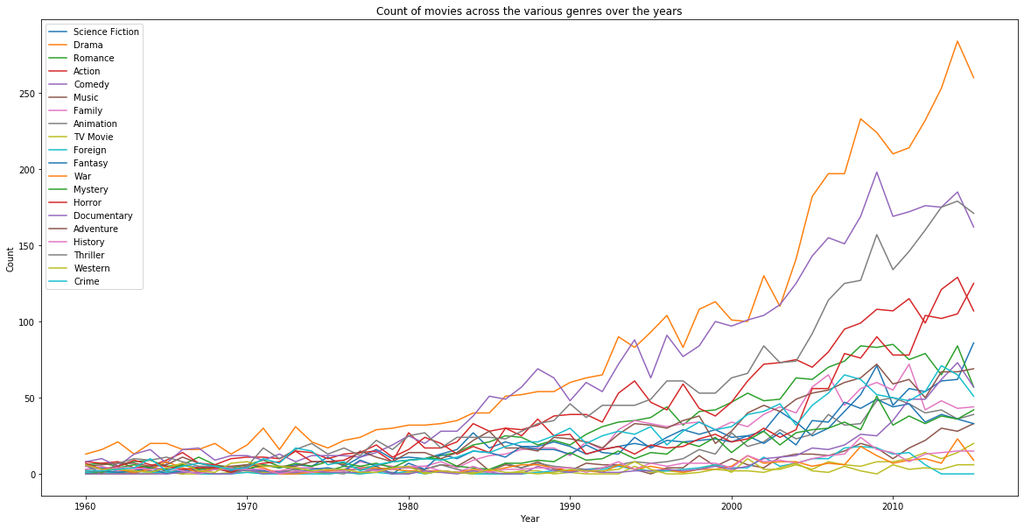

```python
columns = histValues.columns
plt.figure(figsize=[20,10])
plt.title('Count of movies across the various genres over the years')
plt.xlabel('Year')
plt.ylabel('Count')
for column in columns:
    plt.plot(histValues.loc[:,column],label=column)
plt.legend(loc='upper left')
```

Let's plot the values for the histpopularValues. Here again, as in the previous graph, Drama movies hold their first place in recent years.In 1977, adventure and action movies were more popular. In the late 1980s, comedies became popular. In 2003, an action movie was popular. In recent years, dramas, action movies, thriller movies and adventure movies have been doing well.

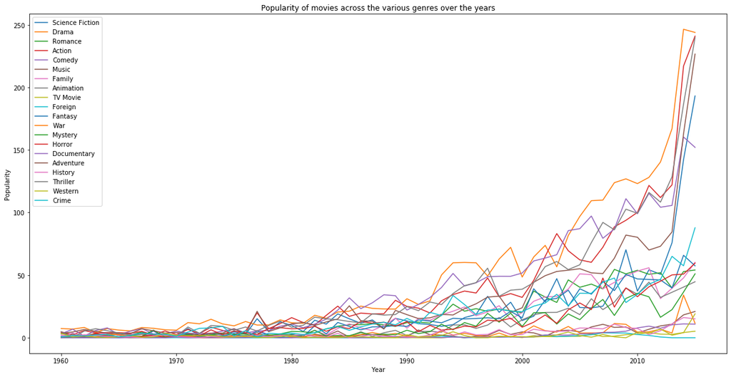

```python
columns = histpopularValues.columns
plt.figure(figsize=[20,10])
plt.title('Popularity of movies across the various genres over the years')
plt.xlabel('Year')
plt.ylabel('Popularity')
for column in columns:
    plt.plot(histpopularValues.loc[:,column],label=column)
plt.legend(loc='upper left')
```

### Research Question 2 What kinds of properties are associated with movies that have high revenues?

Let us investigate using the popular_df dataframe. Does popularity and runtime have an effect on revenue? I plan to use revenue_adj as it will give all the years an equal standing.

I had assumed that popularity would have a positive correlationship with revenue. But it does not seem to be the case. Even for high popularities, the revenue is in the mid-range.

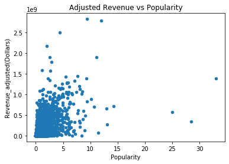

```python
ax=popular_df.plot(x='popularity',y='revenue_adj',kind='scatter',title='Adjusted Revenue vs Popularity')
ax.set_ylabel('Revenue_adjusted(Dollars)');
ax.set_xlabel('Popularity');
```

Let us check the impact of revenue on runtime.

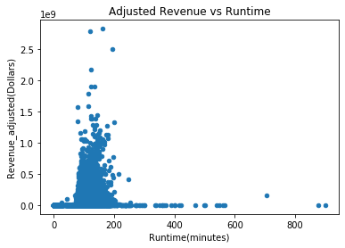

```python
ax2=popular_df.plot(x='runtime',y='revenue_adj',kind='scatter',title='Adjusted Revenue vs Runtime')
ax2.set_ylabel('Revenue_adjusted(Dollars)');
ax2.set_xlabel('Runtime(minutes)');
```

Let's remove the zero valued columns in revenue_adj and see the results. It follows a normal distribution with the highest revenues between 100 and 200 minutes.

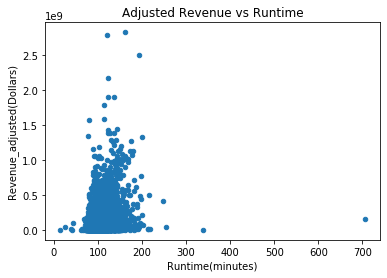

```python
ax3=popular_df[popular_df!=0.0].plot(x='runtime',y='revenue_adj',kind='scatter',title='Adjusted Revenue vs Runtime')
ax3.set_ylabel('Revenue_adjusted(Dollars)')
ax3.set_xlabel('Runtime(minutes)');
```

## Conclusions

Drama movies seem to have a slight edge over other genres. Revenue does not seem to have a correlation with popularity while it seems to have a normal shaped distribution with respect to runtime.

## References

1. [Add x an y labels](https://stackoverflow.com/questions/21487329/add-x-and-y-labels-to-a-pandas-plot)
2. [Line plots](https://www.kaggle.com/andyxie/matplotlib-plot-multiple-lines)
3. [Pandas documentation](https://pandas.pydata.org/pandas-docs/stable/reference/groupby.html)